# R4DS - Exploratory Data Analysis

Simon Thornewill von Essen

3/7/2020

## What is EDA

EDA is the cycle of asking questions about the data, answering these questions through data analysis and then using what we learned to generate new questions. As we continue to go through this cycle, we hopefully start to understand our data on a deeper level.

Note that this is a creative process that depends a lot of skill and experience as well as asking the right questions instead of having a lot of “low quality” questions.

## Variation

As an example, the first questions we tend to ask about our data are ones of variation. “How does x change with respect to y?”

Variables can be categorical, such as we see below…

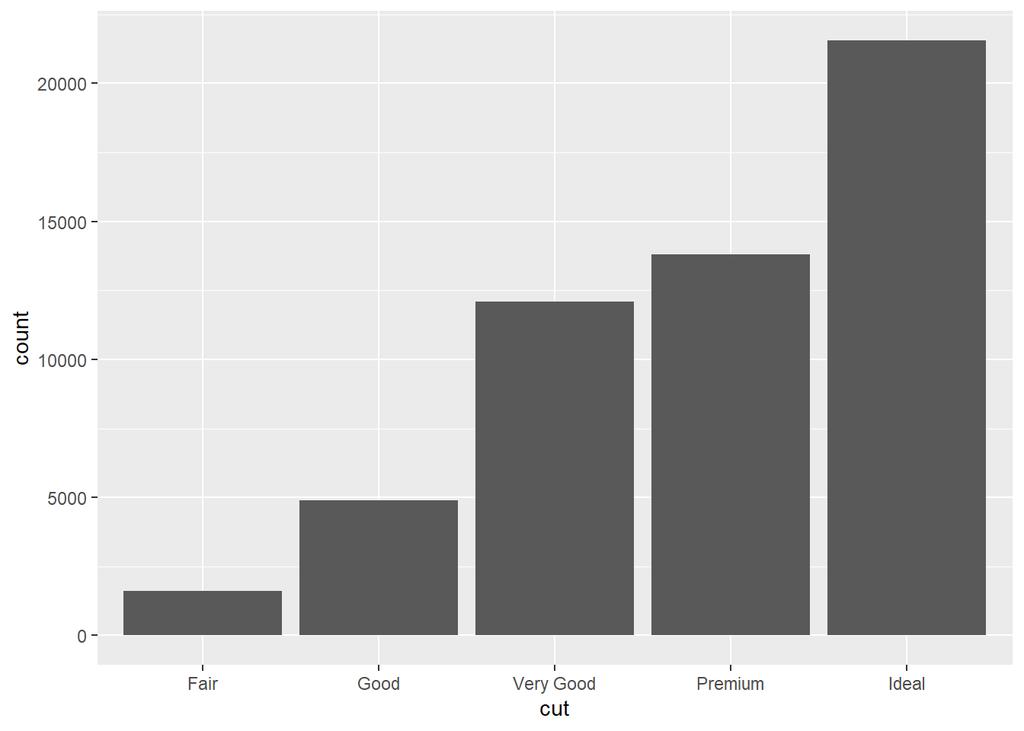

```r
ggplot(data=diamonds) +
  geom_bar(mapping = aes(x=cut))
```

Note that we can get this bar chart in a table by using dplyr:

```r
diamonds %>%
  count(cut)
```

```
## # A tibble: 5 x 2
##   cut           n
##   <ord>     <int>
## 1 Fair       1610
## 2 Good       4906
## 3 Very Good 12082
## 4 Premium   13791
## 5 Ideal     21551
```

We can also get continuous variables

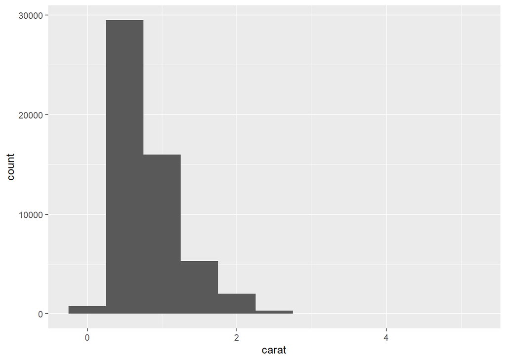

```r
ggplot(data = diamonds) +
  geom_histogram(mapping = aes(x = carat), binwidth = 0.5)
```

So, how would we generate this histogram in tabular format? The `count` function allows us to `cut_width` to create bins which we then use for counting

```r
diamonds %>%
  count(cut_width(carat, 0.5))
```

```
## # A tibble: 11 x 2
##    `cut_width(carat, 0.5)`     n
##    <fct>                   <int>
##  1 [-0.25,0.25]              785
##  2 (0.25,0.75]             29498
##  3 (0.75,1.25]             15977
##  4 (1.25,1.75]              5313
##  5 (1.75,2.25]              2002
##  6 (2.25,2.75]               322
##  7 (2.75,3.25]                32
##  8 (3.25,3.75]                 5
##  9 (3.75,4.25]                 4
## 10 (4.25,4.75]                 1
## 11 (4.75,5.25]                 1
```

Note that setting the binwidth is something that is usually done through trial and error and can be difficult to set algorithmically.

## Typical Values

We can use histograms to show which values are more frqeunt than others and which don’t appear at all:

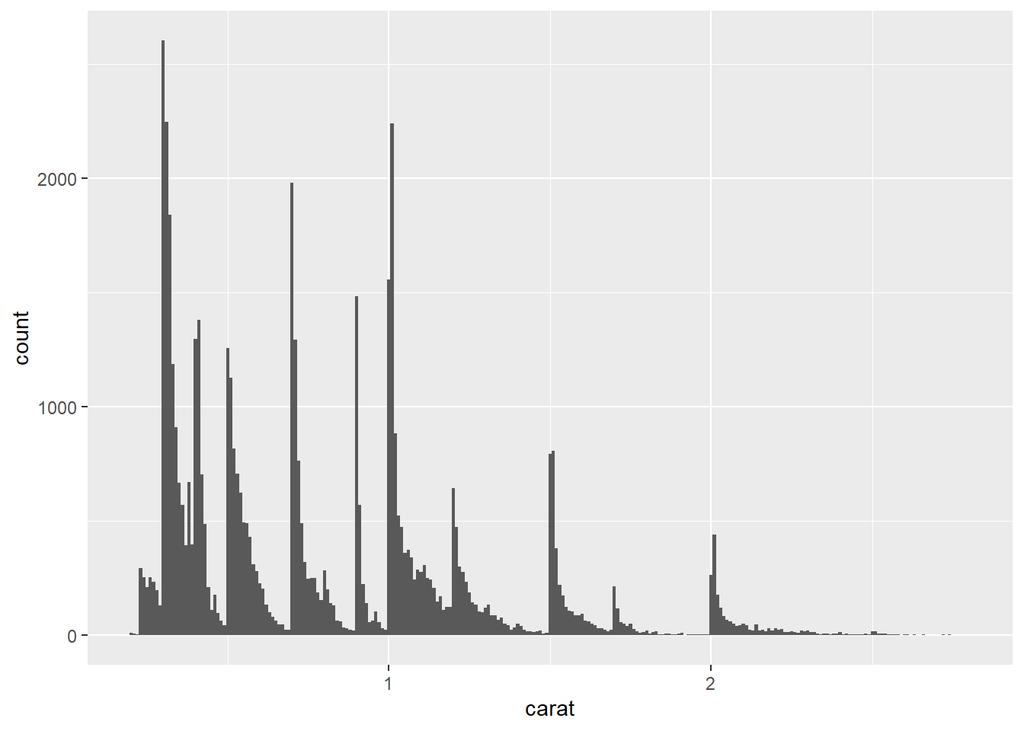

```r
smaller <- diamonds %>%
  filter(carat < 3)


ggplot(data = smaller, mapping = aes(x = carat)) +
  geom_histogram(binwidth = 0.01)
```

This histogram poses a couple of questions:

- Why are there more diamonds at whole carats rather than fractions?
- Why are there more carats slightly to the right than to the left of each peack?
- Why are there no diamonds bigger than 3 carats?

## Covariation

If variabtion explains variance within a varaible, covariation explains variance between variables, this is to plot for trends of multiple features to behave in a similar way.

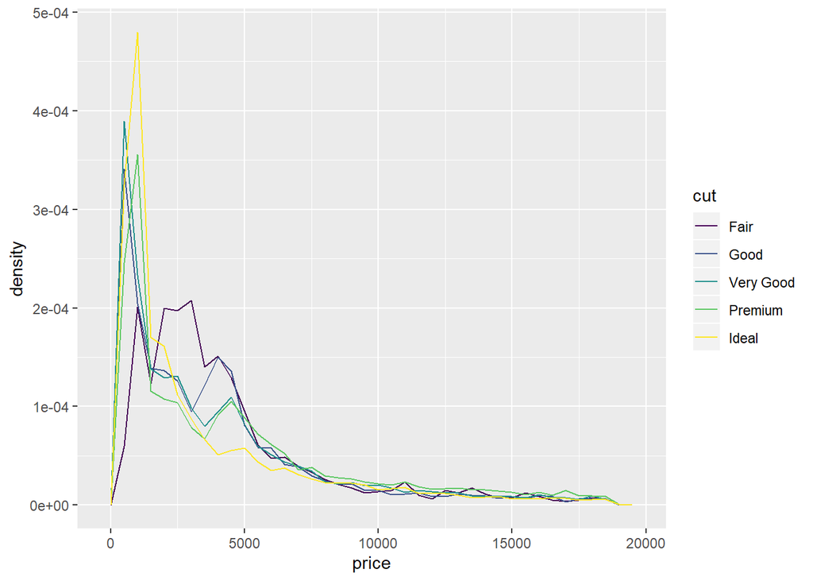

```r
ggplot(data = diamonds, mapping = aes(x = price, y = ..density..)) +
  geom_freqpoly(mapping = aes(colour = cut), binwidth = 500)
```

Here, we can see the average price for fair diamonds are the highest, which is quite surprising. This might be because frequency polygons are a little difficult to inpterpret.

We can use a boxplot to help us to visualise distributions.

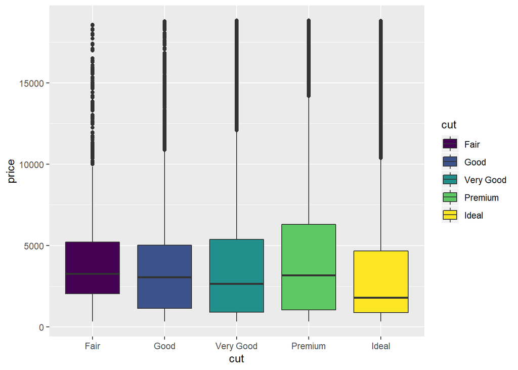

```r
ggplot(data = diamonds, mapping = aes(x = cut, y = price)) +
  geom_boxplot(aes(fill=cut))
```

There is less information about the distribution than the linechart shown above, but at least this way the information is more compact and easier to understand.

You might also want to understand how the cut correlated with color, these are two categorical variables which can be visualised using a scatter plot

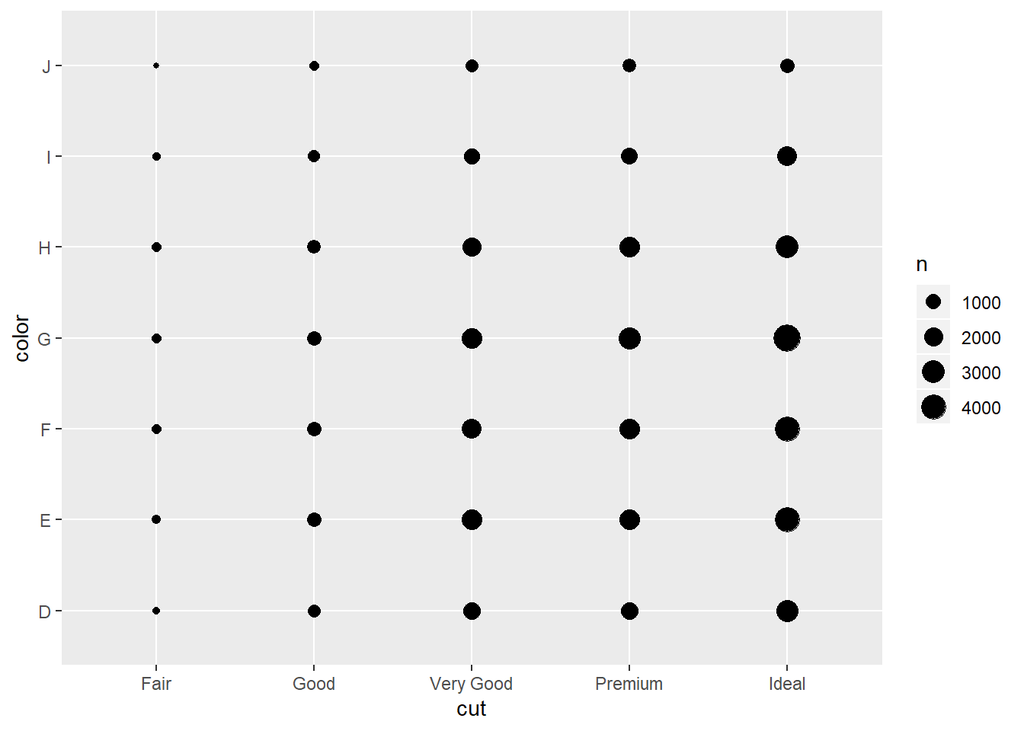

```r
ggplot(data=diamonds) +
  geom_count(mapping=aes(x=cut, y=color))
```

The only difficulty is that the size of a dot can be hard to interpret, we can also use a tile geom to help us to figure things out using colours.

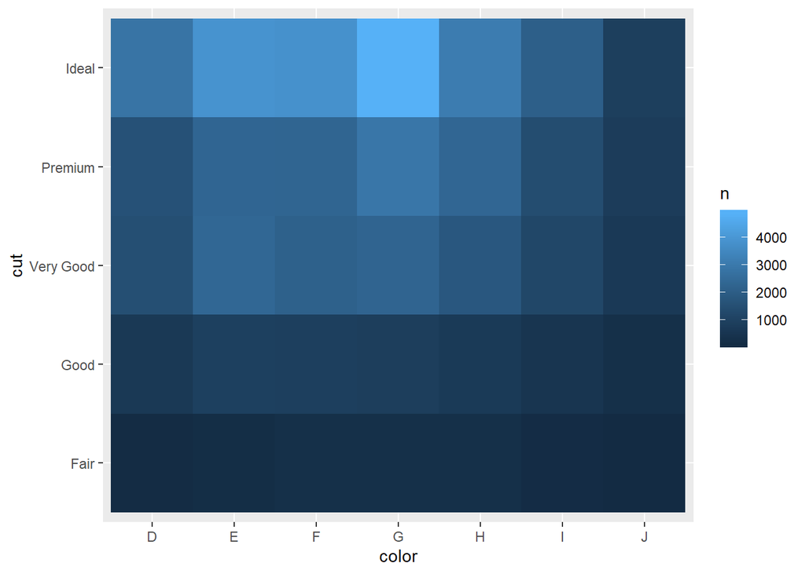

```r
diamonds %>%
  count(color, cut) %>%  # I dintk now you could pipe directly into a ggplot
  ggplot(mapping = aes(x = color, y = cut)) +
    geom_tile(mapping = aes(fill = n))
```

We can also create scatterplots for continuous variables

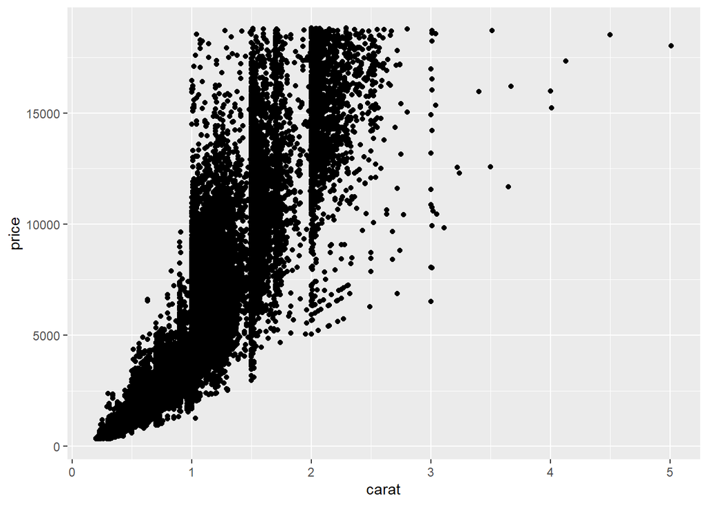

```r
ggplot(data = diamonds) +
  geom_point(mapping = aes(x = carat, y = price))
```

Note that here we get some overplotting, if we reduce the alpha then we can plot all of the data without things getting to noisey, reducing the alpha can help a lot with identifying underlying trends.

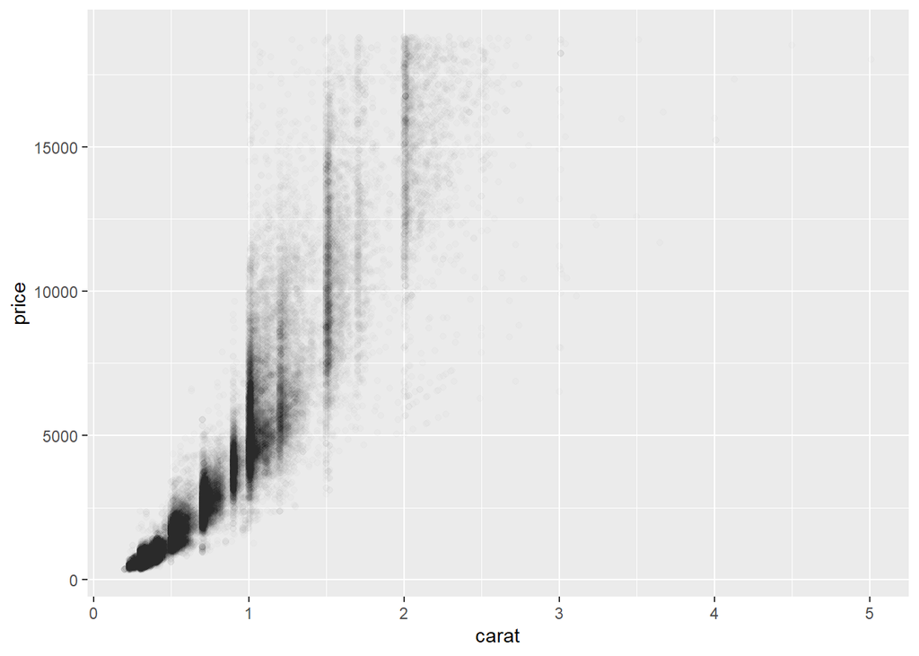

```r
ggplot(data = diamonds) +
  geom_point(mapping = aes(x = carat, y = price), alpha = 1 / 100)
```

However, for large datasets, reducing the alpha can be quite expensive and it might be more useful to bin information together.

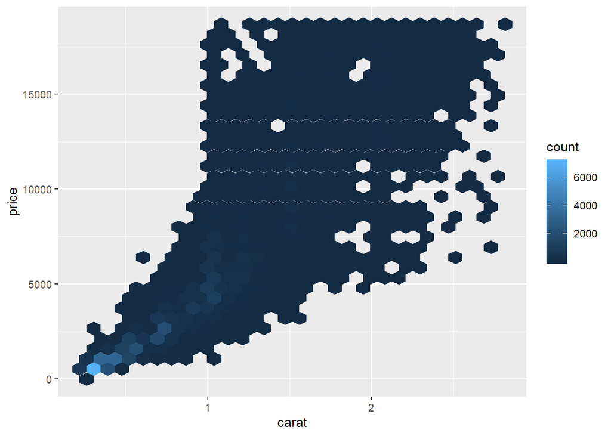

```r
ggplot(data = smaller) +
  geom_hex(mapping = aes(x = carat, y = price))
```

Note that these tools are very powerful for data scientists because it allows us to understand the data which allows us to build models for prediction.